# Activity: Nuclear Reactors

Dave Friedman

19 Jun 2023

```r
library(lubridate)
library(rvest)
library(tidyverse)
str_c('EXECUTED : ', now())
```

```
[1] "EXECUTED : 2023-06-20 01:02:21.364377"
```

```
EXECUTED : 2023-06-20 01:02:21.364377
```

## Scrape the Data

```r
page      <- 'https://en.wikipedia.org/wiki/List_of_commerical_nuclear_reactors'
tableList <-
  page %>%
    read_html() %>%
    html_nodes(css = 'table') %>%
    html_table(fill = TRUE)
length(tableList)
```

```
[1] 55
```

```r
Japan <-
  tableList[[21]] %>%
    select(1:9)
#names(Japan)[c(3, 6)] <- c('type', 'grossMW')
head(Japan)
```

| Plantname | UnitNo. | Type | Model | Status | Capacity(MW) | Beginbuilding | Commercialoperation | Closed |
| --- | --- | --- | --- | --- | --- | --- | --- | --- |
| Plantname | UnitNo. | Type | Model | Status | Capacity(MW) | Beginbuilding | Commercialoperation | Closed |
| Fukushima Daiichi | 1 | BWR | BWR-3 | Inoperable | 439 | 25 Jul 1967 | 26 Mar 1971 | 19 May 2011 |
| Fukushima Daiichi | 2 | BWR | BWR-4 | Inoperable | 760 | 9 Jun 1969 | 18 Jul 1974 | 19 May 2011 |
| Fukushima Daiichi | 3 | BWR | BWR-4 | Inoperable | 760 | 28 Dec 1970 | 27 Mar 1976 | 19 May 2011 |
| Fukushima Daiichi | 4 | BWR | BWR-4 | Inoperable | 760 | 12 Feb 1973 | 12 Oct 1978 | 19 May 2011 |
| Fukushima Daiichi | 5 | BWR | BWR-4 | Shut down | 760 | 22 May 1972 | 18 Apr 1978 | 17 Dec 2013 |

```r
Japan <-
  Japan %>%
    filter(row_number() > 1) %>%
    rename(
      name         = Plantname,
      reactor      = `UnitNo.`,
      type         = Type,
      model        = Model,
      status       = Status,
      netMW        = `Capacity(MW)`,
      construction = Beginbuilding,
      operation    = Commercialoperation,
      closure      = Closed
    )
head(Japan)
```

| name | reactor | type | model | status | netMW | construction | operation | closure |
| --- | --- | --- | --- | --- | --- | --- | --- | --- |
| Fukushima Daiichi | 1 | BWR | BWR-3 | Inoperable | 439 | 25 Jul 1967 | 26 Mar 1971 | 19 May 2011 |
| Fukushima Daiichi | 2 | BWR | BWR-4 | Inoperable | 760 | 9 Jun 1969 | 18 Jul 1974 | 19 May 2011 |
| Fukushima Daiichi | 3 | BWR | BWR-4 | Inoperable | 760 | 28 Dec 1970 | 27 Mar 1976 | 19 May 2011 |
| Fukushima Daiichi | 4 | BWR | BWR-4 | Inoperable | 760 | 12 Feb 1973 | 12 Oct 1978 | 19 May 2011 |
| Fukushima Daiichi | 5 | BWR | BWR-4 | Shut down | 760 | 22 May 1972 | 18 Apr 1978 | 17 Dec 2013 |
| Fukushima Daiichi | 6 | BWR | BWR-5 | Shut down | 1067 | 26 Oct 1973 | 24 Oct 1979 | 17 Dec 2013 |

```r
str(Japan)
```

```
tibble [68 × 9] (S3: tbl_df/tbl/data.frame)
 $ name        : chr [1:68] "Fukushima Daiichi" "Fukushima Daiichi" "Fukushima Daiichi" "Fukushima Daiichi" ...
 $ reactor     : chr [1:68] "1" "2" "3" "4" ...
 $ type        : chr [1:68] "BWR" "BWR" "BWR" "BWR" ...
 $ model       : chr [1:68] "BWR-3" "BWR-4" "BWR-4" "BWR-4" ...
 $ status      : chr [1:68] "Inoperable" "Inoperable" "Inoperable" "Inoperable" ...
 $ netMW       : chr [1:68] "439" "760" "760" "760" ...
 $ construction: chr [1:68] "25 Jul 1967" "9 Jun 1969" "28 Dec 1970" "12 Feb 1973" ...
 $ operation   : chr [1:68] "26 Mar 1971" "18 Jul 1974" "27 Mar 1976" "12 Oct 1978" ...
 $ closure     : chr [1:68] "19 May 2011" "19 May 2011" "19 May 2011" "19 May 2011" ...
```

```r
Japan <-
  Japan %>%
    mutate(
      netMW        = as.integer(netMW),
      construction = lubridate::dmy(construction),
      operation    = lubridate::dmy(operation),
      closure      = lubridate::dmy(closure)
    )
head(Japan)
```

| name | reactor | type | model | status | netMW | construction | operation | closure |
| --- | --- | --- | --- | --- | --- | --- | --- | --- |
| Fukushima Daiichi | 1 | BWR | BWR-3 | Inoperable | 439 | 1967-07-25 | 1971-03-26 | 2011-05-19 |
| Fukushima Daiichi | 2 | BWR | BWR-4 | Inoperable | 760 | 1969-06-09 | 1974-07-18 | 2011-05-19 |
| Fukushima Daiichi | 3 | BWR | BWR-4 | Inoperable | 760 | 1970-12-28 | 1976-03-27 | 2011-05-19 |
| Fukushima Daiichi | 4 | BWR | BWR-4 | Inoperable | 760 | 1973-02-12 | 1978-10-12 | 2011-05-19 |
| Fukushima Daiichi | 5 | BWR | BWR-4 | Shut down | 760 | 1972-05-22 | 1978-04-18 | 2013-12-17 |
| Fukushima Daiichi | 6 | BWR | BWR-5 | Shut down | 1067 | 1973-10-26 | 1979-10-24 | 2013-12-17 |

## Your turn: In what ways is the table tidy? How is it not tidy? What’s different about it from a tidy table?

Tidy Data Criteria * (i) rows (or cases, observations) must each represent the same underlying attribute (i.e., each observation must have its own row) * (ii) columns (or variables, values) must each contain the same type of value for each row (i.e., each variable must have its own column) * (iii) each value must have its own cell * It’s impossible to only satisfy two of the three criteria. This implies the following. * (i) put each dataset into a tibble * (ii) put each variable into a column

There is at least one row that does not represent a typical case (that is, the header row(s)). Certain columns are blank and need to be removed. The remaining columns may contain heterogeneous data formats or data types. And missing values must be addressed. But with some cleaning, the table hints at what a typical case should look like.

## Your Turn: Plot Net Generation Capacity vs Construction Date

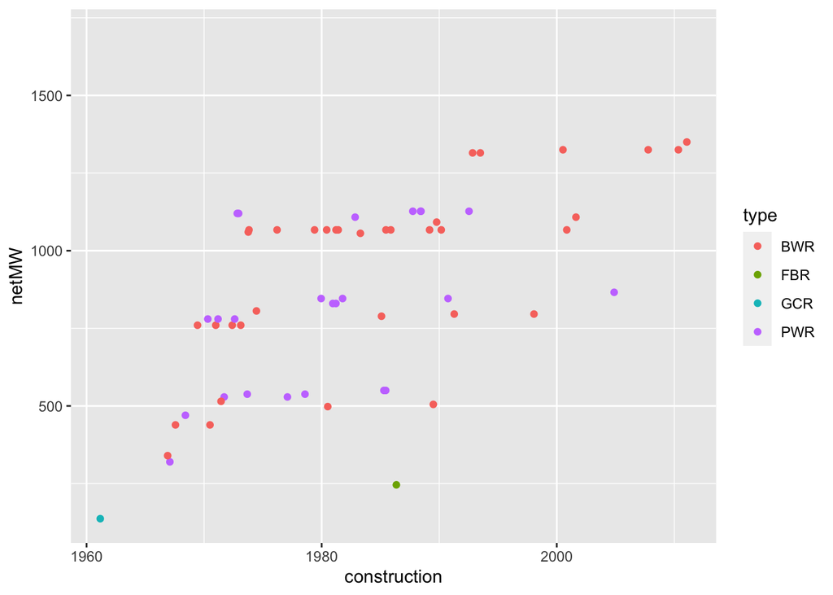

```r
Japan %>%
  ggplot(mapping = aes(x = construction, y = netMW)) +
    geom_point(aes(color = type))
```

## Your Turn: Scrape & Clean China Data (then merge with Japan)

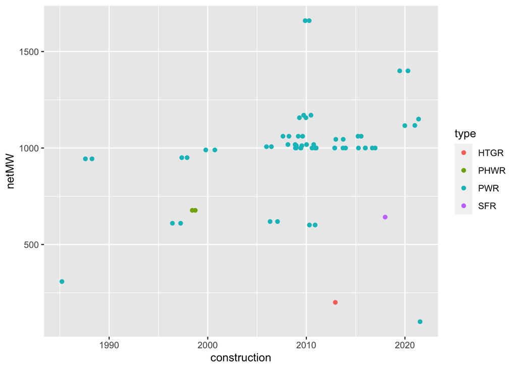

```r
China <-
  tableList[[10]] %>%
    select(1:9)
China <-
  China %>%
    filter(row_number() > 2) %>%
    rename(
      name         = Plantname,
      reactor      = `UnitNo.`,
      type         = Type,
      model        = Model,
      status       = Status,
      netMW        = `Capacity(MW)`,
      construction = Beginbuilding,
      operation    = Commercialoperation,
      closure      = Closed
    )
China <-
  China %>%
    mutate(
      netMW        = as.integer(netMW),
      construction = lubridate::dmy(construction),
      operation    = lubridate::dmy(operation),
      closure      = lubridate::dmy(closure)
    )
China %>%
  ggplot(mapping = aes(x = construction, y = netMW)) +
    geom_point(aes(color = type))
```

```r
bind_rows(Japan, China) %>%
  mutate(Country = ifelse(name %in% unique(Japan$name), 'Japan', 'China')) %>%
  head()
```

| name | reactor | type | model | status | netMW | construction | operation | closure | Country |
| --- | --- | --- | --- | --- | --- | --- | --- | --- | --- |
| Fukushima Daiichi | 1 | BWR | BWR-3 | Inoperable | 439 | 1967-07-25 | 1971-03-26 | 2011-05-19 | Japan |
| Fukushima Daiichi | 2 | BWR | BWR-4 | Inoperable | 760 | 1969-06-09 | 1974-07-18 | 2011-05-19 | Japan |
| Fukushima Daiichi | 3 | BWR | BWR-4 | Inoperable | 760 | 1970-12-28 | 1976-03-27 | 2011-05-19 | Japan |
| Fukushima Daiichi | 4 | BWR | BWR-4 | Inoperable | 760 | 1973-02-12 | 1978-10-12 | 2011-05-19 | Japan |
| Fukushima Daiichi | 5 | BWR | BWR-4 | Shut down | 760 | 1972-05-22 | 1978-04-18 | 2013-12-17 | Japan |
| Fukushima Daiichi | 6 | BWR | BWR-5 | Shut down | 1067 | 1973-10-26 | 1979-10-24 | 2013-12-17 | Japan |

## Your Turn: Reconstruct Info Graphic of Japan Reactors (or other country of interest)

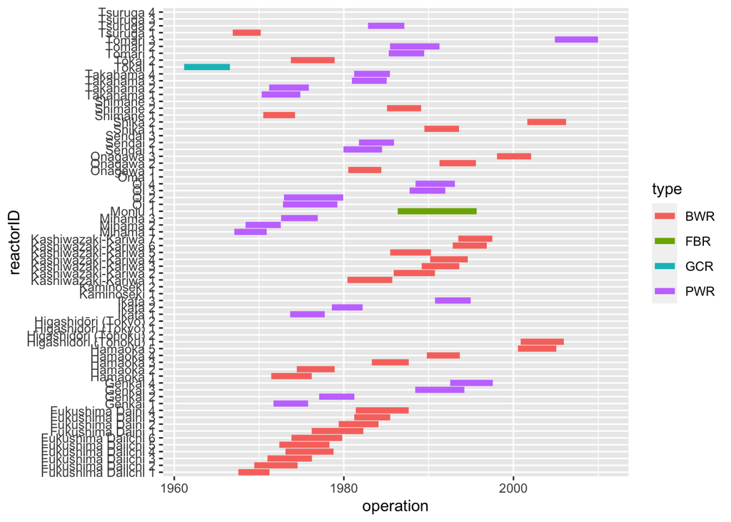

```r
Japan %>%
  mutate(
    reactorID = paste(name, reactor),
    time      = operation - construction
  ) %>%
  ggplot() +
    geom_segment(
      linewidth = 2,
      mapping = aes(
        x     = operation,
        xend  = construction,
        y     = reactorID,
        yend  = reactorID,
        color = type
      )
    )
```